# **Exploratory Data Analysis (EDA) of the Student Satisfaction Survey.**

**1 . Importing Libraries.**

**2. Loading Dataset.**

|  | SN | Total Feedback Given | Total Configured | Questions | Weightage 1 | Weightage 2 | Weightage 3 | Weightage 4 | Weightage 5 | Average/ Percentage | Course Name | Basic Course |
| --- | --- | --- | --- | --- | --- | --- | --- | --- | --- | --- | --- | --- |
| 0 | 1 | 1 | 12 | How much of the syllabus was covered in the cl... | 0 | 0 | 1 | 0 | 0 | 3.00 / 60.00 | FY B.VOC FOOD TECHNOLOGY | B.VOC FOOD TECHNOLOGY |
| 1 | 2 | 1 | 12 | How well did the teachers prepare for the clas... | 0 | 0 | 0 | 0 | 1 | 5.00 / 100.00 | FY B.VOC FOOD TECHNOLOGY | B.VOC FOOD TECHNOLOGY |
| 2 | 3 | 1 | 12 | How well were the teachers able to communicate? | 0 | 0 | 0 | 0 | 1 | 5.00 / 100.00 | FY B.VOC FOOD TECHNOLOGY | B.VOC FOOD TECHNOLOGY |
| 3 | 4 | 1 | 12 | The teachers approach to teaching can best be... | 0 | 0 | 1 | 0 | 0 | 3.00 / 60.00 | FY B.VOC FOOD TECHNOLOGY | B.VOC FOOD TECHNOLOGY |
| 4 | 5 | 1 | 12 | Fairness of the internal evaluation process by... | 0 | 0 | 0 | 1 | 0 | 4.00 / 80.00 | FY B.VOC FOOD TECHNOLOGY | B.VOC FOOD TECHNOLOGY |
| ... | ... | ... | ... | ... | ... | ... | ... | ... | ... | ... | ... | ... |
| 575 | 16 | 9 | 170 | The institute/ teachers use student-centric me... | 1 | 0 | 0 | 2 | 6 | 4.33 / 86.67 | TYBSC | BACHELOR OF SCIENCE |
| 576 | 17 | 9 | 170 | Teachers encourage you to participate in extra... | 0 | 0 | 0 | 3 | 6 | 4.67 / 93.33 | TYBSC | BACHELOR OF SCIENCE |
| 577 | 18 | 9 | 170 | Efforts are made by the institute/ teachers to... | 0 | 0 | 1 | 2 | 6 | 4.56 / 91.11 | TYBSC | BACHELOR OF SCIENCE |
| 578 | 19 | 9 | 170 | What percentage of teachers use ICT tools such... | 0 | 0 | 1 | 3 | 5 | 4.44 / 88.89 | TYBSC | BACHELOR OF SCIENCE |
| 579 | 20 | 9 | 170 | The overall quality of the teaching-learning p... | 0 | 0 | 1 | 2 | 6 | 4.56 / 91.11 | TYBSC | BACHELOR OF SCIENCE |

580 rows × 12 columns

**3. Exploring the data.**

|  | SN | Total Feedback Given | Total Configured | Questions | Weightage 1 | Weightage 2 | Weightage 3 | Weightage 4 | Weightage 5 | Average/ Percentage | Course Name | Basic Course |
| --- | --- | --- | --- | --- | --- | --- | --- | --- | --- | --- | --- | --- |
| 0 | 1 | 1 | 12 | How much of the syllabus was covered in the cl... | 0 | 0 | 1 | 0 | 0 | 3.00 / 60.00 | FY B.VOC FOOD TECHNOLOGY | B.VOC FOOD TECHNOLOGY |
| 1 | 2 | 1 | 12 | How well did the teachers prepare for the clas... | 0 | 0 | 0 | 0 | 1 | 5.00 / 100.00 | FY B.VOC FOOD TECHNOLOGY | B.VOC FOOD TECHNOLOGY |
| 2 | 3 | 1 | 12 | How well were the teachers able to communicate? | 0 | 0 | 0 | 0 | 1 | 5.00 / 100.00 | FY B.VOC FOOD TECHNOLOGY | B.VOC FOOD TECHNOLOGY |
| 3 | 4 | 1 | 12 | The teachers approach to teaching can best be... | 0 | 0 | 1 | 0 | 0 | 3.00 / 60.00 | FY B.VOC FOOD TECHNOLOGY | B.VOC FOOD TECHNOLOGY |
| 4 | 5 | 1 | 12 | Fairness of the internal evaluation process by... | 0 | 0 | 0 | 1 | 0 | 4.00 / 80.00 | FY B.VOC FOOD TECHNOLOGY | B.VOC FOOD TECHNOLOGY |
| 5 | 6 | 1 | 12 | Was your performance in assignments discussed ... | 0 | 0 | 0 | 1 | 0 | 4.00 / 80.00 | FY B.VOC FOOD TECHNOLOGY | B.VOC FOOD TECHNOLOGY |
| 6 | 7 | 1 | 12 | The institute takes an active interest in prom... | 0 | 0 | 1 | 0 | 0 | 3.00 / 60.00 | FY B.VOC FOOD TECHNOLOGY | B.VOC FOOD TECHNOLOGY |
| 7 | 8 | 1 | 12 | The teaching and mentoring process in your ins... | 0 | 1 | 0 | 0 | 0 | 2.00 / 40.00 | FY B.VOC FOOD TECHNOLOGY | B.VOC FOOD TECHNOLOGY |
| 8 | 9 | 1 | 12 | The institution provides multiple opportunitie... | 0 | 0 | 0 | 1 | 0 | 4.00 / 80.00 | FY B.VOC FOOD TECHNOLOGY | B.VOC FOOD TECHNOLOGY |
| 9 | 10 | 1 | 12 | Teachers inform you about your expected compet... | 0 | 0 | 1 | 0 | 0 | 3.00 / 60.00 | FY B.VOC FOOD TECHNOLOGY | B.VOC FOOD TECHNOLOGY |

|  | SN | Total Feedback Given | Total Configured | Questions | Weightage 1 | Weightage 2 | Weightage 3 | Weightage 4 | Weightage 5 | Average/ Percentage | Course Name | Basic Course |
| --- | --- | --- | --- | --- | --- | --- | --- | --- | --- | --- | --- | --- |
| 575 | 16 | 9 | 170 | The institute/ teachers use student-centric me... | 1 | 0 | 0 | 2 | 6 | 4.33 / 86.67 | TYBSC | BACHELOR OF SCIENCE |
| 576 | 17 | 9 | 170 | Teachers encourage you to participate in extra... | 0 | 0 | 0 | 3 | 6 | 4.67 / 93.33 | TYBSC | BACHELOR OF SCIENCE |
| 577 | 18 | 9 | 170 | Efforts are made by the institute/ teachers to... | 0 | 0 | 1 | 2 | 6 | 4.56 / 91.11 | TYBSC | BACHELOR OF SCIENCE |
| 578 | 19 | 9 | 170 | What percentage of teachers use ICT tools such... | 0 | 0 | 1 | 3 | 5 | 4.44 / 88.89 | TYBSC | BACHELOR OF SCIENCE |
| 579 | 20 | 9 | 170 | The overall quality of the teaching-learning p... | 0 | 0 | 1 | 2 | 6 | 4.56 / 91.11 | TYBSC | BACHELOR OF SCIENCE |

**4. Checking data type and their count.**

```
<class 'pandas.core.frame.DataFrame'>
RangeIndex: 580 entries, 0 to 579
Data columns (total 12 columns):
 #   Column                Non-Null Count  Dtype
---  ------                --------------  -----
 0   SN                    580 non-null    int64
 1   Total Feedback Given  580 non-null    int64
 2   Total Configured      580 non-null    int64
 3   Questions             580 non-null    object
 4   Weightage 1           580 non-null    int64
 5   Weightage 2           580 non-null    int64
 6   Weightage 3           580 non-null    int64
 7   Weightage 4           580 non-null    int64
 8   Weightage 5           580 non-null    int64
 9   Average/ Percentage   580 non-null    object
 10  Course Name           580 non-null    object
 11  Basic Course          580 non-null    object
dtypes: int64(8), object(4)
memory usage: 54.5+ KB
```

**5. Checking For Null Values.**

```
SN                      0
Total Feedback Given    0
Total Configured        0
Questions               0
Weightage 1             0
Weightage 2             0
Weightage 3             0
Weightage 4             0
Weightage 5             0
Average/ Percentage     0
Course Name             0
Basic Course            0
dtype: int64
```

**Observation:** There are no Null Values in data.

**6. Checking For Duplicates in Data.**

```
Number of duplicate entries: 0
```

**Observation:** There are no Duplicates in data.

**7. Statistical Summary.**

|  | SN | Total Feedback Given | Total Configured | Weightage 1 | Weightage 2 | Weightage 3 | Weightage 4 | Weightage 5 |
| --- | --- | --- | --- | --- | --- | --- | --- | --- |
| count | 580.000000 | 580.000000 | 580.000000 | 580.000000 | 580.000000 | 580.000000 | 580.000000 | 580.000000 |
| mean | 10.500000 | 14.310345 | 92.517241 | 0.527586 | 1.187931 | 2.537931 | 5.082759 | 4.974138 |
| std | 5.771259 | 16.488031 | 114.491780 | 1.305336 | 1.686334 | 3.193302 | 7.288293 | 6.494931 |
| min | 1.000000 | 1.000000 | 12.000000 | 0.000000 | 0.000000 | 0.000000 | 0.000000 | 0.000000 |
| 25% | 5.750000 | 3.000000 | 20.000000 | 0.000000 | 0.000000 | 0.000000 | 1.000000 | 1.000000 |
| 50% | 10.500000 | 7.000000 | 42.000000 | 0.000000 | 0.000000 | 1.000000 | 3.000000 | 3.000000 |
| 75% | 15.250000 | 17.000000 | 123.000000 | 1.000000 | 2.000000 | 3.250000 | 6.000000 | 6.000000 |
| max | 20.000000 | 74.000000 | 559.000000 | 19.000000 | 8.000000 | 26.000000 | 52.000000 | 38.000000 |

**8. Checking For Unique Values and spellings or variables in Data.**

```
Index(['SN', 'Total Feedback Given', 'Total Configured', 'Questions',
       'Weightage 1', 'Weightage 2', 'Weightage 3', 'Weightage 4',
       'Weightage 5', 'Average/ Percentage', 'Course Name ', 'Basic Course'],
      dtype='object')
```

```
SN                       20
Total Feedback Given     18
Total Configured         24
Questions                20
Weightage 1              11
Weightage 2               9
Weightage 3              19
Weightage 4              36
Weightage 5              35
Average/ Percentage     152
Course Name              29
Basic Course             16
dtype: int64
```

```
array(['How much of the syllabus was covered in the class?',
       'How well did the teachers prepare for the classes?',
       'How well were the teachers able to communicate?',
       'The teacher\x92s approach to teaching can best be described as',
       'Fairness of the internal evaluation process by the teachers.',
       'Was your performance in assignments discussed with you?',
       'The institute takes an active interest in promoting internships, student exchange, field visit opportunities for students.',
       'The teaching and mentoring process in your institution facilitates you in cognitive, social and\nemotional growth.',
       'The institution provides multiple opportunities to learn and grow.',
       'Teachers inform you about your expected competencies, course outcomes and program\noutcomes.',
       'Your mentor does a necessary follow-up with an assigned task to you.',
       'The teachers illustrate the concepts through examples and applications.',
       'The teachers identify your strengths and encourage you to provide the proper level of challenges.',
       'Teachers are able to identify your weaknesses and help you to overcome them.',
       'The institution makes effort to engage students in the monitoring, review and continuous quality improvement of the teaching-learning process.',
       'The institute/ teachers use student-centric methods, such as experiential learning, participative learning and problem-solving methodologies for enhancing learning experiences.',
       'Teachers encourage you to participate in extracurricular activities.',
       'Efforts are made by the institute/ teachers to inculcate soft skills, life skills and employability skills to make you ready for the world of work.',
       'What percentage of teachers use ICT tools such as LCD projectors, Multimedia, etc. while teaching?',
       'The overall quality of the teaching-learning process in your institute is very good.'],
      dtype=object)
```

```
array(['B.VOC FOOD TECHNOLOGY', 'BACHELOR OF ARTS',
       'BACHELOR OF COMMERCE (ACCOUNTING AND FINANCE)',
       'BACHELOR OF COMMERCE (BANKING AND INSURANCE)',
       'BACHELOR OF MANAGEMENT STUDIES', 'BACHELOR OF SCIENCE',
       'MA PSYCHOLOGY', 'MSC COMPUTER SCIENCE',
       'MSC ANALYTICAL CHEMISTRY', 'MSC DATA SCIENCE',
       'MSC INFORMATION TECHNOLOGY', 'MSC MICROBIOLOGY',
       'MSC ORGANIC CHEMISTRY', 'MSC PHYSICS', 'BACHELOR OF COMMERCE',
       'B.SC. COMPUTER SCIENCE'], dtype=object)
```

```
array([ 12, 144, 119,  33, 122, 175,  15,  20,  24,  42,  21,  44,  14,
        22,  18, 137, 559, 123, 159,  48, 118, 331, 105, 170], dtype=int64)
```

```
array([ 1, 74, 20, 26, 12,  5,  7,  4,  2,  3, 14,  6, 17, 46, 37, 27, 39,
        9], dtype=int64)
```

**1. Average Feedbacks given by different Departments for each Question.**

```
Basic Course
B.SC. COMPUTER SCIENCE                           27.000000
B.VOC FOOD TECHNOLOGY                             1.000000
BACHELOR OF ARTS                                  9.000000
BACHELOR OF COMMERCE                             38.000000
BACHELOR OF COMMERCE (ACCOUNTING AND FINANCE)    60.000000
BACHELOR OF COMMERCE (BANKING AND INSURANCE)     20.000000
BACHELOR OF MANAGEMENT STUDIES                   12.333333
BACHELOR OF SCIENCE                               9.333333
MA PSYCHOLOGY                                     6.000000
MSC ANALYTICAL CHEMISTRY                          8.000000
MSC COMPUTER SCIENCE                              5.500000
MSC DATA SCIENCE                                  3.000000
MSC INFORMATION TECHNOLOGY                        3.500000
MSC MICROBIOLOGY                                  8.500000
MSC ORGANIC CHEMISTRY                            17.000000
MSC PHYSICS                                       2.000000
Name: Total Feedback Given, dtype: float64
```

**2. List of total strength of the batch in Different Courses.**

```
    Total Configured                                   Basic Course   0
0                 12                          B.VOC FOOD TECHNOLOGY  20
1                 14                               MSC DATA SCIENCE  20
2                 15                                  MA PSYCHOLOGY  20
3                 18                                    MSC PHYSICS  20
4                 20                                  MA PSYCHOLOGY  20
5                 20                           MSC COMPUTER SCIENCE  20
6                 20                               MSC DATA SCIENCE  20
7                 20                     MSC INFORMATION TECHNOLOGY  20
8                 21                     MSC INFORMATION TECHNOLOGY  20
9                 22                          MSC ORGANIC CHEMISTRY  20
10                24                           MSC COMPUTER SCIENCE  20
11                24                               MSC MICROBIOLOGY  40
12                33   BACHELOR OF COMMERCE (BANKING AND INSURANCE)  20
13                42                       MSC ANALYTICAL CHEMISTRY  20
14                44                       MSC ANALYTICAL CHEMISTRY  20
15                48                         B.SC. COMPUTER SCIENCE  20
16               105                 BACHELOR OF MANAGEMENT STUDIES  20
17               118                               BACHELOR OF ARTS  20
18               119  BACHELOR OF COMMERCE (ACCOUNTING AND FINANCE)  20
19               122                 BACHELOR OF MANAGEMENT STUDIES  20
20               123                 BACHELOR OF MANAGEMENT STUDIES  20
21               137  BACHELOR OF COMMERCE (ACCOUNTING AND FINANCE)  20
22               144                               BACHELOR OF ARTS  20
23               159                            BACHELOR OF SCIENCE  20
24               170                            BACHELOR OF SCIENCE  20
25               175                            BACHELOR OF SCIENCE  20
26               331                           BACHELOR OF COMMERCE  20
27               559                           BACHELOR OF COMMERCE  20
```

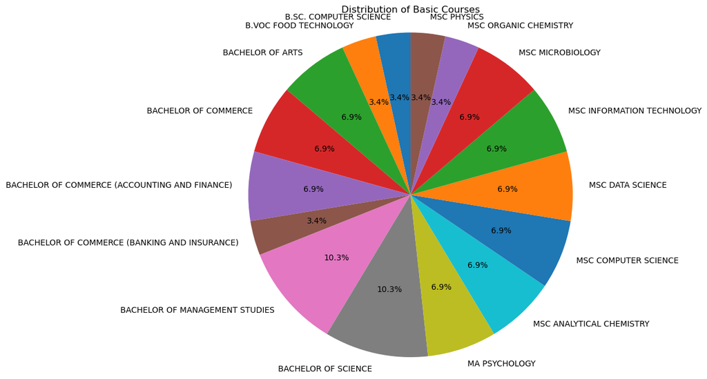

**3. Average Rating Given by Different Departments Across 20 Questions ?**

```
Average rating by course:
Basic Course
B.SC. COMPUTER SCIENCE                           3.354500
B.VOC FOOD TECHNOLOGY                            3.400000
BACHELOR OF ARTS                                 4.335000
BACHELOR OF COMMERCE                             3.719000
BACHELOR OF COMMERCE (ACCOUNTING AND FINANCE)    4.075500
BACHELOR OF COMMERCE (BANKING AND INSURANCE)     4.350000
BACHELOR OF MANAGEMENT STUDIES                   4.092167
BACHELOR OF SCIENCE                              3.852667
MA PSYCHOLOGY                                    3.600500
MSC ANALYTICAL CHEMISTRY                         4.033750
MSC COMPUTER SCIENCE                             3.845500
MSC DATA SCIENCE                                 3.050500
MSC INFORMATION TECHNOLOGY                       4.354500
MSC MICROBIOLOGY                                 3.538000
MSC ORGANIC CHEMISTRY                            3.972500
MSC PHYSICS                                      3.425000
Name: Average/ Percentage, dtype: float64

Overall average rating across all courses:
3.812442708333333
```

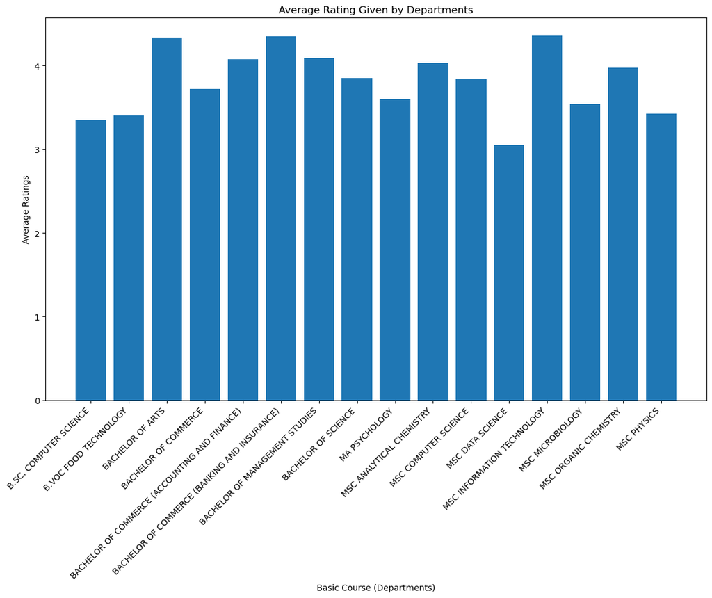

```
Average average rating by course (sum of average ratings across 20 questions):
Basic Course
B.SC. COMPUTER SCIENCE                           3.354500
B.VOC FOOD TECHNOLOGY                            3.400000
BACHELOR OF ARTS                                 4.335000
BACHELOR OF COMMERCE                             3.719000
BACHELOR OF COMMERCE (ACCOUNTING AND FINANCE)    4.075500
BACHELOR OF COMMERCE (BANKING AND INSURANCE)     4.350000
BACHELOR OF MANAGEMENT STUDIES                   4.092167
BACHELOR OF SCIENCE                              3.852667
MA PSYCHOLOGY                                    3.600500
MSC ANALYTICAL CHEMISTRY                         4.033750
MSC COMPUTER SCIENCE                             3.845500
MSC DATA SCIENCE                                 3.050500
MSC INFORMATION TECHNOLOGY                       4.354500
MSC MICROBIOLOGY                                 3.538000
MSC ORGANIC CHEMISTRY                            3.972500
MSC PHYSICS                                      3.425000
Name: Average/ Percentage, dtype: float64

Overall average average rating across all courses:
3.812442708333333
```

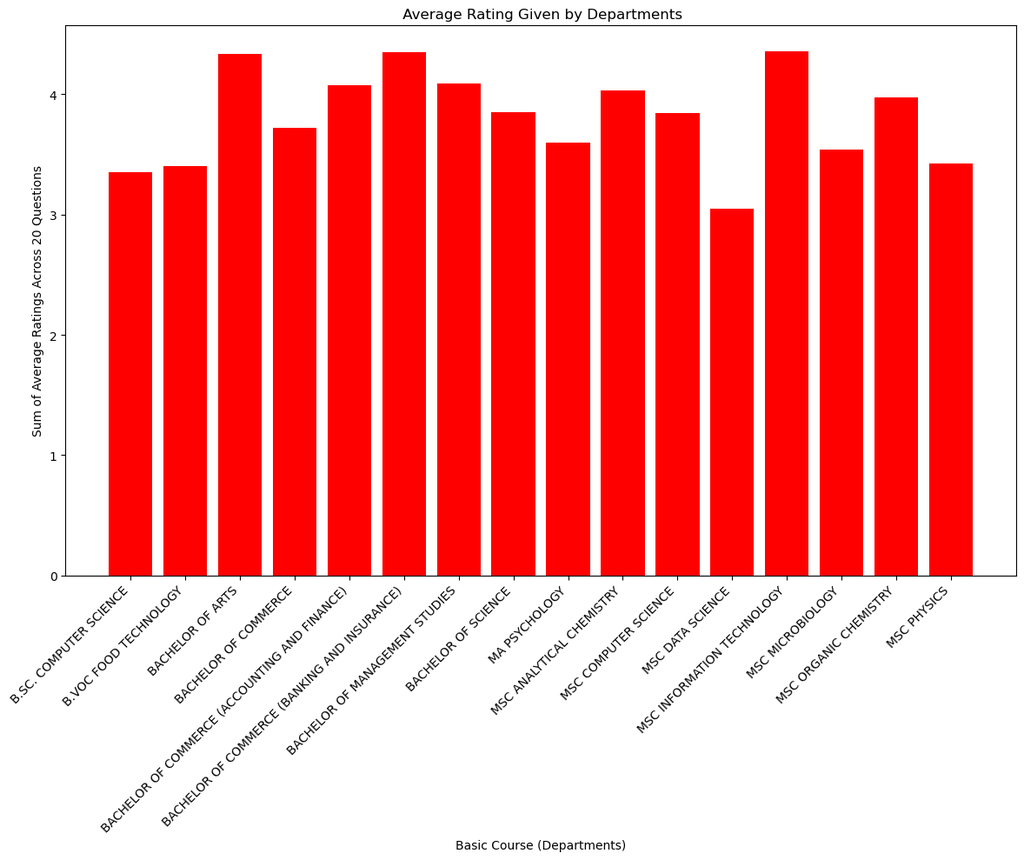

**Observations on Average Average Rating by Course:**

**Higher Average Ratings:**

**Lower Average Ratings:**

# **1. Understanding Student Experience: Insights from Satisfaction Survey**

**1. How much of the syllabus was covered in the class ?**

```
Basic Course
B.SC. COMPUTER SCIENCE                           3.560000
B.VOC FOOD TECHNOLOGY                            3.000000
BACHELOR OF ARTS                                 4.325000
BACHELOR OF COMMERCE                             3.760000
BACHELOR OF COMMERCE (ACCOUNTING AND FINANCE)    4.345000
BACHELOR OF COMMERCE (BANKING AND INSURANCE)     4.700000
BACHELOR OF MANAGEMENT STUDIES                   3.840000
BACHELOR OF SCIENCE                              4.053333
MA PSYCHOLOGY                                    3.370000
MSC ANALYTICAL CHEMISTRY                         4.430000
MSC COMPUTER SCIENCE                             4.410000
MSC DATA SCIENCE                                 3.335000
MSC INFORMATION TECHNOLOGY                       4.835000
MSC MICROBIOLOGY                                 3.480000
MSC ORGANIC CHEMISTRY                            4.120000
MSC PHYSICS                                      3.000000
Name: Average/ Percentage, dtype: float64

Min & Max:
min    3.000
max    4.835
Name: Average/ Percentage, dtype: float64
```

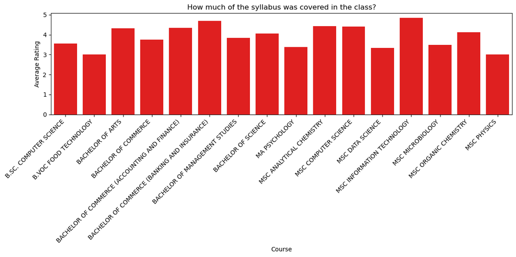

**Observation.** Here are some observations you can make about the data for question 1: "How much of the syllabus was covered in the class?"

**Overall Coverage:**

It's difficult to determine a single "coverage" value for the entire dataset. The provided values indicate a range of coverage from 3.00 (lowest) to 4.84 (highest). Course Types:

**Outliers:**

**2. How well did the teachers prepare for the classes ?**

```
Basic Course
B.SC. COMPUTER SCIENCE                           3.560000
B.VOC FOOD TECHNOLOGY                            5.000000
BACHELOR OF ARTS                                 4.675000
BACHELOR OF COMMERCE                             3.815000
BACHELOR OF COMMERCE (ACCOUNTING AND FINANCE)    3.945000
BACHELOR OF COMMERCE (BANKING AND INSURANCE)     4.050000
BACHELOR OF MANAGEMENT STUDIES                   4.233333
BACHELOR OF SCIENCE                              4.210000
MA PSYCHOLOGY                                    3.645000
MSC ANALYTICAL CHEMISTRY                         4.285000
MSC COMPUTER SCIENCE                             4.020000
MSC DATA SCIENCE                                 3.670000
MSC INFORMATION TECHNOLOGY                       4.250000
MSC MICROBIOLOGY                                 3.690000
MSC ORGANIC CHEMISTRY                            4.180000
MSC PHYSICS                                      4.500000
Name: Average/ Percentage, dtype: float64
```

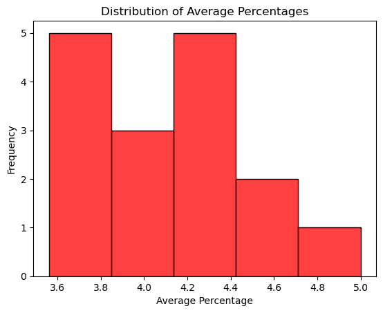

```
min    3.56
max    5.00
Name: Average/ Percentage, dtype: float64
```

**Observation.** Here are some observations you can make about the data for question 2: "How well did the teachers prepare for the classes?"

**Teacher Preparation:**

The data suggests a range of perceived teacher preparedness, from 3.56 (lowest) to 5.00 (highest). This indicates that students have varying opinions about how well teachers prepared for classes. **Course Types:**

**B.VOC FOOD TECHNOLOGY:** This course has the highest reported teacher preparedness (5.00). It's worth considering if this exceptional rating reflects a unique situation or represents the general perception for this course. There are no clear outliers on the low end.

**3. How well were the teachers able to communicate ?**

```
Basic Course
B.SC. COMPUTER SCIENCE                           3.630
B.VOC FOOD TECHNOLOGY                            5.000
BACHELOR OF ARTS                                 4.735
BACHELOR OF COMMERCE                             4.145
BACHELOR OF COMMERCE (ACCOUNTING AND FINANCE)    4.355
BACHELOR OF COMMERCE (BANKING AND INSURANCE)     4.500
BACHELOR OF MANAGEMENT STUDIES                   4.170
BACHELOR OF SCIENCE                              4.320
MA PSYCHOLOGY                                    3.685
MSC ANALYTICAL CHEMISTRY                         4.215
MSC COMPUTER SCIENCE                             4.230
MSC DATA SCIENCE                                 3.165
MSC INFORMATION TECHNOLOGY                       4.585
MSC MICROBIOLOGY                                 4.165
MSC ORGANIC CHEMISTRY                            4.060
MSC PHYSICS                                      4.500
Name: Average/ Percentage, dtype: float64
```

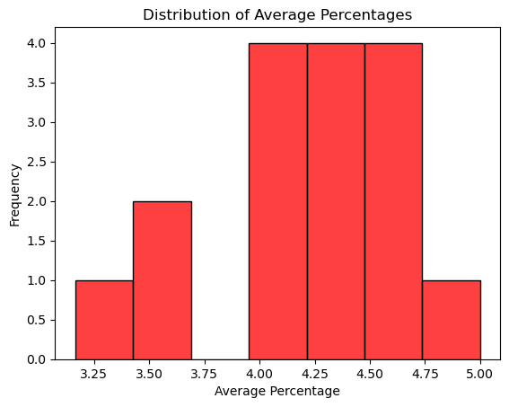

```
min    3.165
max    5.000
Name: Average/ Percentage, dtype: float64
```

**Observation :** Here are some observations you can make about the data for question 3: "How well were the teachers able to communicate?"

**Teacher Communication:**

The data suggests a range of perceived teacher communication skills, from 3.165 (lowest) to 5.00 (highest). This indicates that students have varying opinions about how effectively teachers communicated the course material. Course Types:

**B.VOC FOOD TECHNOLOGY:** This course has the highest reported teacher communication rating (5.00). It's worth considering if this exceptional rating reflects a unique situation or represents the general perception for this course. MSC DATA SCIENCE: This course has the lowest reported teacher communication rating (3.165). It might be valuable to investigate why students felt the communication in this course was less effective.

**4. The teachers approach to teaching can best be described as ?**

```
Basic Course
B.SC. COMPUTER SCIENCE                           3.220
B.VOC FOOD TECHNOLOGY                            3.000
BACHELOR OF ARTS                                 4.470
BACHELOR OF COMMERCE                             3.720
BACHELOR OF COMMERCE (ACCOUNTING AND FINANCE)    3.985
BACHELOR OF COMMERCE (BANKING AND INSURANCE)     4.350
BACHELOR OF MANAGEMENT STUDIES                   3.930
BACHELOR OF SCIENCE                              3.740
MA PSYCHOLOGY                                    3.370
MSC ANALYTICAL CHEMISTRY                         3.535
MSC COMPUTER SCIENCE                             3.645
MSC DATA SCIENCE                                 2.835
MSC INFORMATION TECHNOLOGY                       4.585
MSC MICROBIOLOGY                                 3.250
MSC ORGANIC CHEMISTRY                            3.880
MSC PHYSICS                                      3.500
Name: Average/ Percentage, dtype: float64
```

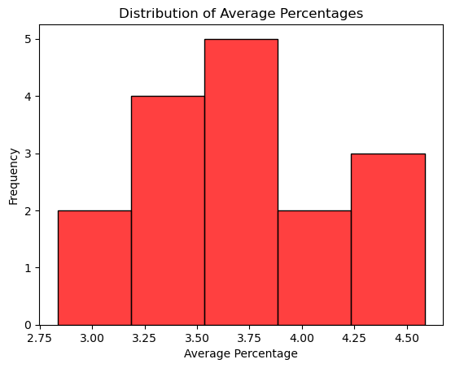

```
min    2.835
max    4.585
Name: Average/ Percentage, dtype: float64
```

**Observation.** Here are some general observations, assuming the ratings could be interpreted as a measure of student satisfaction with the teaching approach:

There's a range of perceived teaching approach effectiveness, from 2.835 (lowest) to 4.585 (highest). Some courses (BACHELOR OF ARTS, MSC INFORMATION TECHNOLOGY) have higher average ratings, suggesting students found the teaching approach more effective in those courses. Other courses (MSC DATA SCIENCE) have lower average ratings, indicating a need to explore how the teaching approach can be improved for those students.

**5. Fairness of the internal evaluation process by the teachers.**

```
Basic Course
B.SC. COMPUTER SCIENCE                           3.410000
B.VOC FOOD TECHNOLOGY                            4.000000
BACHELOR OF ARTS                                 4.765000
BACHELOR OF COMMERCE                             3.895000
BACHELOR OF COMMERCE (ACCOUNTING AND FINANCE)    4.280000
BACHELOR OF COMMERCE (BANKING AND INSURANCE)     4.450000
BACHELOR OF MANAGEMENT STUDIES                   4.170000
BACHELOR OF SCIENCE                              4.033333
MA PSYCHOLOGY                                    4.415000
MSC ANALYTICAL CHEMISTRY                         4.285000
MSC COMPUTER SCIENCE                             4.305000
MSC DATA SCIENCE                                 3.835000
MSC INFORMATION TECHNOLOGY                       4.750000
MSC MICROBIOLOGY                                 3.905000
MSC ORGANIC CHEMISTRY                            4.410000
MSC PHYSICS                                      4.500000
Name: Average/ Percentage, dtype: float64
```

```
min    3.410
max    4.765
Name: Average/ Percentage, dtype: float64
```

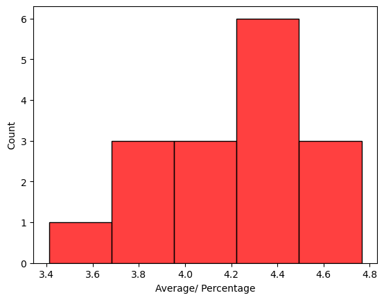

**Observation.** Here's a summary of the data for question 5: "Fairness of the internal evaluation process by the teachers."

**Perceived Fairness:**

The data shows a range of perceptions regarding fairness in the internal evaluation process, from 3.41 (lowest) to 4.765 (highest). This indicates that students have varying opinions on how fair the evaluation process was in different courses. **Course Types:**

**BACHELOR OF ARTS:** This course has the highest reported fairness rating (4.765). It might be worth investigating if this exceptional rating reflects a unique situation or represents the general perception for this course. B.SC. COMPUTER SCIENCE: This course has the lowest reported fairness rating (3.41). It might be valuable to explore why students felt the evaluation process in this course was less fair.

**6. Was your performance in assignments discussed with you?**

```
Basic Course
B.SC. COMPUTER SCIENCE                           3.520000
B.VOC FOOD TECHNOLOGY                            4.000000
BACHELOR OF ARTS                                 4.325000
BACHELOR OF COMMERCE                             3.750000
BACHELOR OF COMMERCE (ACCOUNTING AND FINANCE)    4.240000
BACHELOR OF COMMERCE (BANKING AND INSURANCE)     4.500000
BACHELOR OF MANAGEMENT STUDIES                   4.140000
BACHELOR OF SCIENCE                              3.646667
MA PSYCHOLOGY                                    3.745000
MSC ANALYTICAL CHEMISTRY                         3.965000
MSC COMPUTER SCIENCE                             4.285000
MSC DATA SCIENCE                                 3.335000
MSC INFORMATION TECHNOLOGY                       4.500000
MSC MICROBIOLOGY                                 3.485000
MSC ORGANIC CHEMISTRY                            3.760000
MSC PHYSICS                                      3.000000
Name: Average/ Percentage, dtype: float64
```

```
min    3.0
max    4.5
Name: Average/ Percentage, dtype: float64
```

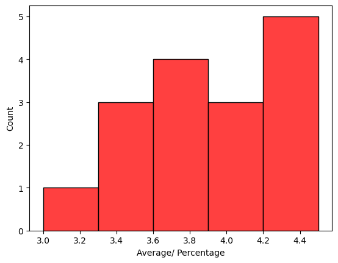

**Observation.** Here's a summary of the data for question 6: "Was your performance in assignments discussed with you?"

**Frequency of Discussions:**

The data shows a range of reported discussions about assignment performance, from 3.00 (lowest) to 4.50 (highest). This suggests that students had varying experiences in terms of how often their assignment performance was discussed with them. **Course Types:**

**BACHELOR OF COMMERCE (BANKING AND INSURANCE):** This course has the highest reported frequency of discussions (4.50). It might be worth investigating if this exceptional rating reflects a unique teaching style or represents the general perception for this course. MSC PHYSICS: This course has the lowest reported frequency of discussions (3.00). It might be valuable to explore why students felt their assignment performance was less frequently discussed in this course.

**7. The institute takes an active interest in promoting internships, student exchange, field visit opportunities for students.**

```
Basic Course
B.SC. COMPUTER SCIENCE                           3.480000
B.VOC FOOD TECHNOLOGY                            3.000000
BACHELOR OF ARTS                                 3.735000
BACHELOR OF COMMERCE                             3.695000
BACHELOR OF COMMERCE (ACCOUNTING AND FINANCE)    3.970000
BACHELOR OF COMMERCE (BANKING AND INSURANCE)     4.500000
BACHELOR OF MANAGEMENT STUDIES                   4.013333
BACHELOR OF SCIENCE                              3.606667
MA PSYCHOLOGY                                    3.730000
MSC ANALYTICAL CHEMISTRY                         3.680000
MSC COMPUTER SCIENCE                             3.250000
MSC DATA SCIENCE                                 2.335000
MSC INFORMATION TECHNOLOGY                       4.250000
MSC MICROBIOLOGY                                 3.690000
MSC ORGANIC CHEMISTRY                            3.940000
MSC PHYSICS                                      2.500000
Name: Average/ Percentage, dtype: float64
```

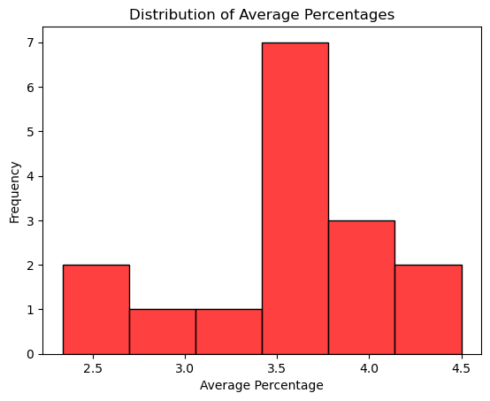

```
min    2.335
max    4.500
Name: Average/ Percentage, dtype: float64
```

**Observation:** Here's a summary of the data for question 7: ". The institute takes an active interest in promoting internships, student exchange, field visit opportunities for students."

**Institute's Initiative:**

The data shows a range of values (2.335 to 4.500) which likely represent student perceptions regarding the institute's efforts to promote opportunities like internships, exchange programs, and field visits. Higher values suggest a stronger perceived initiative. **Course Types:**

**BACHELOR OF COMMERCE (BANKING AND INSURANCE):** This course has the highest reported value (4.500), indicating students perceive the institute to be very active in promoting these opportunities for this course. **MSC DATA SCIENCE & MSC PHYSICS:** These courses have the lowest reported values (2.335 & 2.500), suggesting students perceive less initiative from the institute in promoting opportunities.

**8. The teaching and mentoring process in your institution facilitates you in cognitive, social and\nemotional growth.**

```
Basic Course
B.SC. COMPUTER SCIENCE                           3.440000
B.VOC FOOD TECHNOLOGY                            2.000000
BACHELOR OF ARTS                                 4.675000
BACHELOR OF COMMERCE                             3.565000
BACHELOR OF COMMERCE (ACCOUNTING AND FINANCE)    3.970000
BACHELOR OF COMMERCE (BANKING AND INSURANCE)     4.350000
BACHELOR OF MANAGEMENT STUDIES                   3.920000
BACHELOR OF SCIENCE                              3.563333
MA PSYCHOLOGY                                    3.515000
MSC ANALYTICAL CHEMISTRY                         4.105000
MSC COMPUTER SCIENCE                             3.445000
MSC DATA SCIENCE                                 2.330000
MSC INFORMATION TECHNOLOGY                       3.500000
MSC MICROBIOLOGY                                 3.215000
MSC ORGANIC CHEMISTRY                            3.880000
MSC PHYSICS                                      3.000000
Name: Average/ Percentage, dtype: float64
```

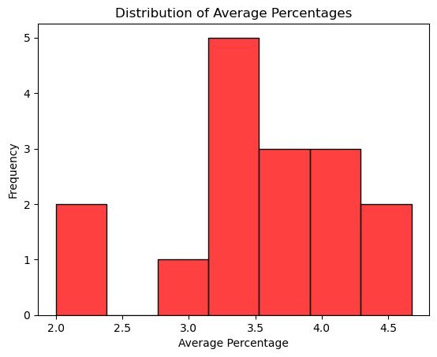

```
min    2.000
max    4.675
Name: Average/ Percentage, dtype: float64
```

**Observation.** Here's a summary of the data for question 8: "The teaching and mentoring process in your institution facilitates you in cognitive, social and emotional growth."

**Overall Growth:**

The data shows a range of values (2.000 to 4.675) which likely represent student perceptions regarding how well the teaching and mentoring process supports their cognitive, social, and emotional growth. Higher values suggest a stronger perceived positive influence. **Course Types:**

**BACHELOR OF ARTS:** This course has the highest reported rating (4.675). It might be worth investigating if there are specific aspects of the teaching and mentoring process in this program that are particularly beneficial for student growth. **B.VOC FOOD TECHNOLOGY & MSC DATA SCIENCE:** These courses have the lowest reported values (2.000 & 2.330), suggesting students perceive less facilitation of their growth in these programs. Investigating these outliers can help identify areas for improvement.

**9. The institution provides multiple opportunities to learn and grow.**

```
Basic Course
B.SC. COMPUTER SCIENCE                           3.480000
B.VOC FOOD TECHNOLOGY                            4.000000
BACHELOR OF ARTS                                 3.940000
BACHELOR OF COMMERCE                             3.645000
BACHELOR OF COMMERCE (ACCOUNTING AND FINANCE)    4.145000
BACHELOR OF COMMERCE (BANKING AND INSURANCE)     4.000000
BACHELOR OF MANAGEMENT STUDIES                   4.276667
BACHELOR OF SCIENCE                              3.880000
MA PSYCHOLOGY                                    3.455000
MSC ANALYTICAL CHEMISTRY                         3.605000
MSC COMPUTER SCIENCE                             3.465000
MSC DATA SCIENCE                                 3.000000
MSC INFORMATION TECHNOLOGY                       4.585000
MSC MICROBIOLOGY                                 3.250000
MSC ORGANIC CHEMISTRY                            4.000000
MSC PHYSICS                                      3.500000
Name: Average/ Percentage, dtype: float64
```

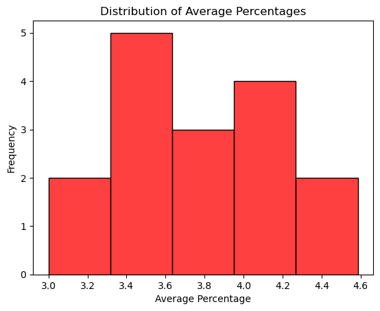

```
min    3.000
max    4.585
Name: Average/ Percentage, dtype: float64
```

**Learning Opportunities:**

The data shows a range of values (3.000 to 4.585) which likely represent student perceptions regarding the availability of opportunities to learn and grow at the institution. Higher values suggest a stronger positive perception.

**Course Types:**

MSC INFORMATION TECHNOLOGY: This course has the highest reported value (4.585), indicating students perceive ample opportunities to learn and grow in this program. MSC DATA SCIENCE: This course has the lowest reported value (3.000), suggesting students perceive fewer opportunities to learn and grow in this program area.

**10. Teachers inform you about your expected competencies, course outcomes and program\noutcomes.**

```
Basic Course
B.SC. COMPUTER SCIENCE                           3.040000
B.VOC FOOD TECHNOLOGY                            3.000000
BACHELOR OF ARTS                                 4.735000
BACHELOR OF COMMERCE                             3.935000
BACHELOR OF COMMERCE (ACCOUNTING AND FINANCE)    4.200000
BACHELOR OF COMMERCE (BANKING AND INSURANCE)     4.500000
BACHELOR OF MANAGEMENT STUDIES                   4.276667
BACHELOR OF SCIENCE                              3.896667
MA PSYCHOLOGY                                    3.915000
MSC ANALYTICAL CHEMISTRY                         4.070000
MSC COMPUTER SCIENCE                             3.500000
MSC DATA SCIENCE                                 3.665000
MSC INFORMATION TECHNOLOGY                       4.750000
MSC MICROBIOLOGY                                 3.450000
MSC ORGANIC CHEMISTRY                            4.410000
MSC PHYSICS                                      3.500000
Name: Average/ Percentage, dtype: float64
```

```
min    3.00
max    4.75
Name: Average/ Percentage, dtype: float64
```

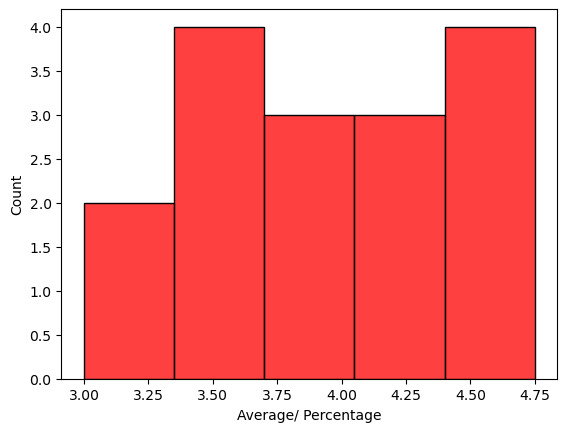

**Observation:**

Here's a summary of the data for question 10: "Teachers inform you about your expected competencies, course outcomes and program outcomes."

Communication of Learning Objectives:

The data shows a range of values (3.000 to 4.750) which likely represent student perceptions regarding how well teachers inform them about what they are expected to learn. Higher values suggest teachers are more successful in communicating these learning objectives.

**Course Types:**

**Outliers:**

**11. Your mentor does a necessary follow-up with an assigned task to you.**

```
Basic Course
B.SC. COMPUTER SCIENCE                           3.370
B.VOC FOOD TECHNOLOGY                            3.000
BACHELOR OF ARTS                                 4.500
BACHELOR OF COMMERCE                             3.715
BACHELOR OF COMMERCE (ACCOUNTING AND FINANCE)    4.115
BACHELOR OF COMMERCE (BANKING AND INSURANCE)     4.100
BACHELOR OF MANAGEMENT STUDIES                   3.570
BACHELOR OF SCIENCE                              3.810
MA PSYCHOLOGY                                    3.930
MSC ANALYTICAL CHEMISTRY                         4.355
MSC COMPUTER SCIENCE                             3.590
MSC DATA SCIENCE                                 3.000
MSC INFORMATION TECHNOLOGY                       3.750
MSC MICROBIOLOGY                                 3.535
MSC ORGANIC CHEMISTRY                            3.760
MSC PHYSICS                                      2.500
Name: Average/ Percentage, dtype: float64
```

```
min    2.5
max    4.5
Name: Average/ Percentage, dtype: float64
```

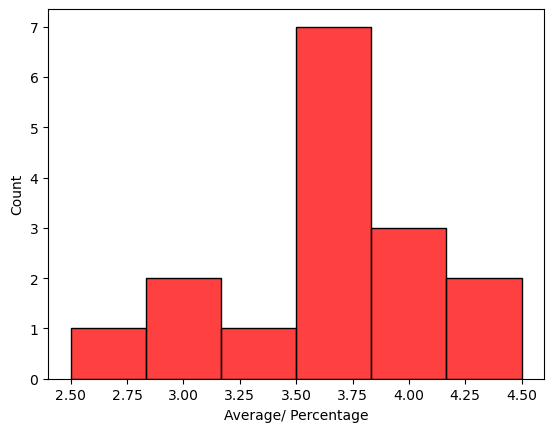

**Observation.**

The data shows a range of values (2.500 to 4.500) which likely represent student perceptions of how well their mentors follow up on assigned tasks. Higher values suggest students perceive more frequent or effective follow-up from their mentors.

**Here's a breakdown of the data:**

**Courses with High Mentor Follow-Up:**

1. BACHELOR OF ARTS (4.500)
2. MSC ANALYTICAL CHEMISTRY (4.355)
3. BACHELOR OF COMMERCE (ACCOUNTING AND FINANCE) (4.115)
4. BACHELOR OF COMMERCE (BANKING AND INSURANCE) (4.100)
5. Courses with Low Mentor Follow-Up:
6. MSC PHYSICS (2.500)
7. MSC DATA SCIENCE (3.000)
8. B.VOC FOOD TECHNOLOGY (3.000)

**12. The teachers illustrate the concepts through examples and applications.**

```
Basic Course
B.SC. COMPUTER SCIENCE                           3.190000
B.VOC FOOD TECHNOLOGY                            5.000000
BACHELOR OF ARTS                                 4.440000
BACHELOR OF COMMERCE                             3.790000
BACHELOR OF COMMERCE (ACCOUNTING AND FINANCE)    4.255000
BACHELOR OF COMMERCE (BANKING AND INSURANCE)     4.100000
BACHELOR OF MANAGEMENT STUDIES                   4.420000
BACHELOR OF SCIENCE                              4.003333
MA PSYCHOLOGY                                    4.170000
MSC ANALYTICAL CHEMISTRY                         4.320000
MSC COMPUTER SCIENCE                             4.285000
MSC DATA SCIENCE                                 2.670000
MSC INFORMATION TECHNOLOGY                       4.750000
MSC MICROBIOLOGY                                 3.395000
MSC ORGANIC CHEMISTRY                            4.240000
MSC PHYSICS                                      4.000000
Name: Average/ Percentage, dtype: float64
```

```
min    2.67
max    5.00
Name: Average/ Percentage, dtype: float64
```

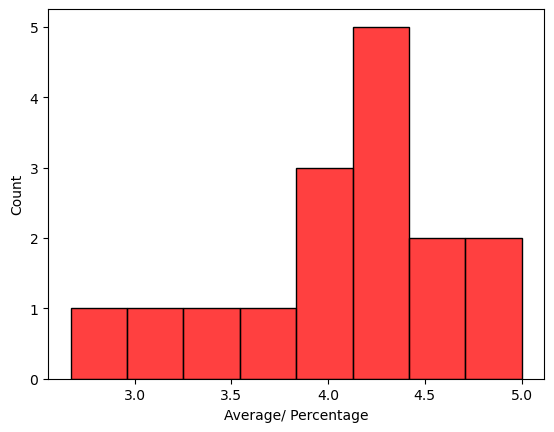

**Courses with Strong Use:**

B.VOC FOOD TECHNOLOGY (highest rating): Students perceive teachers to be exceptionally effective at using examples and applications (5.000000). MSC INFORMATION TECHNOLOGY (4.750000) BACHELOR OF MANAGEMENT STUDIES (4.420000) BACHELOR OF ARTS (4.440000)

**Courses with Lower Use:**

MSC DATA SCIENCE (lowest rating): Students perceive teachers to be less effective at using examples and applications (2.670000). Other courses with values below 4.000000 might also warrant attention.

**13. The teachers identify your strengths and encourage you to provide the proper level of challenges.**

```
Basic Course
B.SC. COMPUTER SCIENCE                           3.440
B.VOC FOOD TECHNOLOGY                            2.000
BACHELOR OF ARTS                                 4.470
BACHELOR OF COMMERCE                             3.870
BACHELOR OF COMMERCE (ACCOUNTING AND FINANCE)    4.200
BACHELOR OF COMMERCE (BANKING AND INSURANCE)     4.400
BACHELOR OF MANAGEMENT STUDIES                   4.080
BACHELOR OF SCIENCE                              3.640
MA PSYCHOLOGY                                    3.230
MSC ANALYTICAL CHEMISTRY                         4.035
MSC COMPUTER SCIENCE                             3.105
MSC DATA SCIENCE                                 1.665
MSC INFORMATION TECHNOLOGY                       4.335
MSC MICROBIOLOGY                                 3.320
MSC ORGANIC CHEMISTRY                            3.880
MSC PHYSICS                                      3.500
Name: Average/ Percentage, dtype: float64
```

```
min    1.665
max    4.470
Name: Average/ Percentage, dtype: float64
```

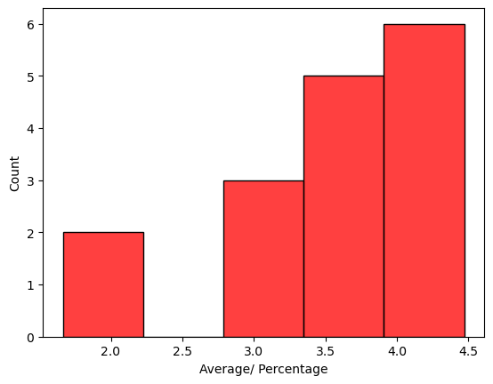

**Observation.**

1. Student perceptions vary on how well teachers identify strengths and provide challenges (1.665 to 4.470).
2. Investigate high ratings (Bachelor of Arts) and low ratings (MSc Data Science) to understand best practices and areas for improvement.
3. Consider clarifying the rating scale and gathering more specific feedback in future surveys.

**14. Teachers are able to identify your weaknesses and help you to overcome them.**

```
Basic Course
B.SC. COMPUTER SCIENCE                           2.930000
B.VOC FOOD TECHNOLOGY                            3.000000
BACHELOR OF ARTS                                 4.530000
BACHELOR OF COMMERCE                             3.670000
BACHELOR OF COMMERCE (ACCOUNTING AND FINANCE)    3.945000
BACHELOR OF COMMERCE (BANKING AND INSURANCE)     4.350000
BACHELOR OF MANAGEMENT STUDIES                   4.543333
BACHELOR OF SCIENCE                              3.603333
MA PSYCHOLOGY                                    2.915000
MSC ANALYTICAL CHEMISTRY                         3.645000
MSC COMPUTER SCIENCE                             3.625000
MSC DATA SCIENCE                                 2.835000
MSC INFORMATION TECHNOLOGY                       4.085000
MSC MICROBIOLOGY                                 3.730000
MSC ORGANIC CHEMISTRY                            3.760000
MSC PHYSICS                                      3.000000
Name: Average/ Percentage, dtype: float64
```

```
min    2.835000
max    4.543333
Name: Average/ Percentage, dtype: float64
```

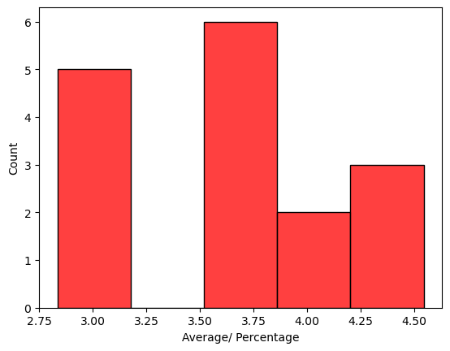

**Observation.**

The data shows students have mixed perceptions (2.835 to 4.543) on how well teachers identify weaknesses and help them improve. Here's a quick summary:

**High Ratings:**

BACHELOR OF ARTS (4.530) & BACHELOR OF MANAGEMENT STUDIES (4.543) - Students perceive teachers are highly effective in this area.

**Low Ratings:**

MSC DATA SCIENCE (2.835) & MA PSYCHOLOGY (2.915) - These courses have the lowest ratings, suggesting room for improvement. Investigate both ends (high & low) to understand best practices and areas for improvement.

**15. The institution makes effort to engage students in the monitoring, review and continuous quality improvement of the teaching-learning process.**

```
Basic Course
B.SC. COMPUTER SCIENCE                           3.370000
B.VOC FOOD TECHNOLOGY                            3.000000
BACHELOR OF ARTS                                 3.970000
BACHELOR OF COMMERCE                             3.580000
BACHELOR OF COMMERCE (ACCOUNTING AND FINANCE)    4.020000
BACHELOR OF COMMERCE (BANKING AND INSURANCE)     4.300000
BACHELOR OF MANAGEMENT STUDIES                   4.246667
BACHELOR OF SCIENCE                              3.863333
MA PSYCHOLOGY                                    3.555000
MSC ANALYTICAL CHEMISTRY                         4.145000
MSC COMPUTER SCIENCE                             3.770000
MSC DATA SCIENCE                                 3.000000
MSC INFORMATION TECHNOLOGY                       4.165000
MSC MICROBIOLOGY                                 3.355000
MSC ORGANIC CHEMISTRY                            3.940000
MSC PHYSICS                                      3.500000
Name: Average/ Percentage, dtype: float64
```

```
min    3.0
max    4.3
Name: Average/ Percentage, dtype: float64
```

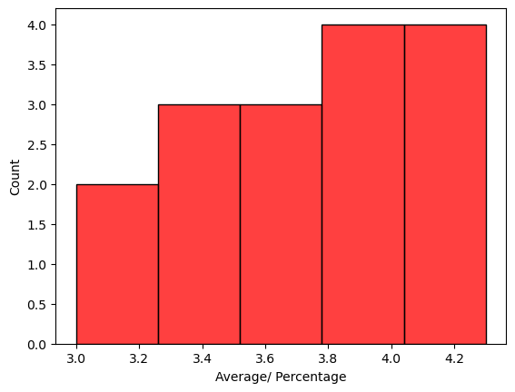

The data shows a range of student perceptions (3.000 to 4.300) on how well the institution engages them in monitoring, reviewing, and improving the teaching-learning process (on a 5-point scale). Here's a breakdown:

**Higher Engagement:**

BACHELOR OF COMMERCE (BANKING AND INSURANCE) (4.300) - Students perceive the strongest efforts to engage them in improvement processes. Other courses with values above 4.000 might also indicate good engagement (e.g., BACHELOR OF COMMERCE (ACCOUNTING AND FINANCE), BACHELOR OF MANAGEMENT STUDIES).

**Lower Engagement:**

B.VOC FOOD TECHNOLOGY & MSC DATA SCIENCE (3.000) - Students perceive the least effort to engage them. Other courses with values below 3.500 might also warrant attention.

**16. The institute/ teachers use student-centric methods, such as experiential learning, participative learning and problem-solving methodologies for enhancing learning experiences.**

```
Basic Course
B.SC. COMPUTER SCIENCE                           3.190000
B.VOC FOOD TECHNOLOGY                            3.000000
BACHELOR OF ARTS                                 4.030000
BACHELOR OF COMMERCE                             3.515000
BACHELOR OF COMMERCE (ACCOUNTING AND FINANCE)    4.025000
BACHELOR OF COMMERCE (BANKING AND INSURANCE)     4.300000
BACHELOR OF MANAGEMENT STUDIES                   4.033333
BACHELOR OF SCIENCE                              3.796667
MA PSYCHOLOGY                                    3.755000
MSC ANALYTICAL CHEMISTRY                         4.395000
MSC COMPUTER SCIENCE                             4.090000
MSC DATA SCIENCE                                 3.170000
MSC INFORMATION TECHNOLOGY                       4.085000
MSC MICROBIOLOGY                                 3.595000
MSC ORGANIC CHEMISTRY                            3.940000
MSC PHYSICS                                      2.500000
Name: Average/ Percentage, dtype: float64
```

```
min    2.500
max    4.395
Name: Average/ Percentage, dtype: float64
```

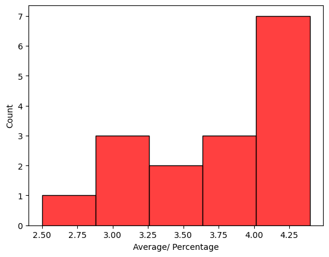

**Observation.**

The data shows a range of student perceptions (2.500 to 4.395) on how well teachers use student-centered methods (on a possible 5-point scale). Here's a breakdown:

**Strong Use of Student-Centered Methods:**

MSC ANALYTICAL CHEMISTRY (4.395) - Students perceive the strongest use of methods like experiential learning, participatory learning, and problem-solving. Other courses with values above 4.000 might also indicate strong use (e.g., BACHELOR OF COMMERCE (BANKING AND INSURANCE), MSC INFORMATION TECHNOLOGY).

**Lower Use of Student-Centered Methods:**

MSC PHYSICS (2.500) - Students perceive the least use of student-centered methods in this program. Other courses with values below 3.500 might also warrant attention.

**17. Teachers encourage you to participate in extracurricular activities.**

```
Basic Course
B.SC. COMPUTER SCIENCE                           3.150000
B.VOC FOOD TECHNOLOGY                            4.000000
BACHELOR OF ARTS                                 4.030000
BACHELOR OF COMMERCE                             3.700000
BACHELOR OF COMMERCE (ACCOUNTING AND FINANCE)    4.285000
BACHELOR OF COMMERCE (BANKING AND INSURANCE)     4.300000
BACHELOR OF MANAGEMENT STUDIES                   4.146667
BACHELOR OF SCIENCE                              4.183333
MA PSYCHOLOGY                                    3.785000
MSC ANALYTICAL CHEMISTRY                         4.000000
MSC COMPUTER SCIENCE                             3.785000
MSC DATA SCIENCE                                 3.335000
MSC INFORMATION TECHNOLOGY                       4.165000
MSC MICROBIOLOGY                                 3.285000
MSC ORGANIC CHEMISTRY                            3.940000
MSC PHYSICS                                      4.000000
Name: Average/ Percentage, dtype: float64
```

```
min    3.15
max    4.30
Name: Average/ Percentage, dtype: float64
```

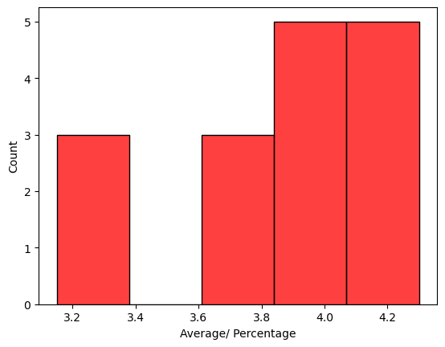

**Observation.**

The data shows a range of student perceptions (3.150 to 4.300) on how well teachers encourage participation in extracurricular activities (on a possible 5-point scale). Here's a summary:

**Strongest Encouragement:**

BACHELOR OF COMMERCE (BANKING AND INSURANCE) (4.300) - Students perceive the most encouragement from teachers to participate in extracurricular activities. Other courses with values above 4.000 might also indicate strong encouragement.

**Lower Encouragement:**

B.SC. COMPUTER SCIENCE (3.150) - Students perceive the least encouragement from teachers in this program. Other courses with values below 3.500 might also warrant attention.

**18. Efforts are made by the institute/ teachers to inculcate soft skills, life skills and employability skills to make you ready for the world of work.**

```
Basic Course
B.SC. COMPUTER SCIENCE                           3.220000
B.VOC FOOD TECHNOLOGY                            2.000000
BACHELOR OF ARTS                                 4.000000
BACHELOR OF COMMERCE                             3.730000
BACHELOR OF COMMERCE (ACCOUNTING AND FINANCE)    4.065000
BACHELOR OF COMMERCE (BANKING AND INSURANCE)     4.350000
BACHELOR OF MANAGEMENT STUDIES                   4.230000
BACHELOR OF SCIENCE                              3.976667
MA PSYCHOLOGY                                    3.485000
MSC ANALYTICAL CHEMISTRY                         4.320000
MSC COMPUTER SCIENCE                             3.945000
MSC DATA SCIENCE                                 3.000000
MSC INFORMATION TECHNOLOGY                       4.750000
MSC MICROBIOLOGY                                 3.730000
MSC ORGANIC CHEMISTRY                            4.000000
MSC PHYSICS                                      3.500000
Name: Average/ Percentage, dtype: float64
```

```
min    2.00
max    4.75
Name: Average/ Percentage, dtype: float64
```

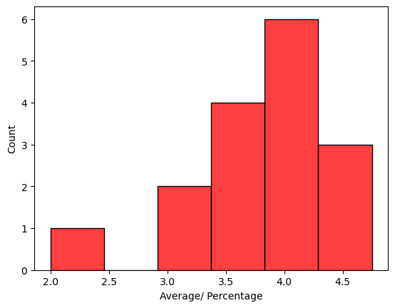

**Observation.**

The data indicates a variation in student perceptions (2.000 to 4.750) on how well the institute and teachers focus on developing soft skills, life skills, and employability skills (on a possible 5-point scale). Here's a breakdown:

**Strongest Efforts:**

MSC INFORMATION TECHNOLOGY (4.750) - Students perceive the strongest efforts in this program to develop well-rounded graduates prepared for the workplace. Other courses with values above 4.000 might also indicate strong efforts (e.g., BACHELOR OF COMMERCE (BANKING AND INSURANCE), BACHELOR OF COMMERCE (ACCOUNTING AND FINANCE), BACHELOR OF MANAGEMENT STUDIES).

**Lower Efforts:**

B.VOC FOOD TECHNOLOGY (2.000) - Students perceive the least effort in this program to develop these skills. Other courses with values below 3.500 might also warrant attention.

**19. What percentage of teachers use ICT tools such as LCD projectors, Multimedia, etc. while teaching?**

```
Basic Course
B.SC. COMPUTER SCIENCE                           3.520000
B.VOC FOOD TECHNOLOGY                            4.000000
BACHELOR OF ARTS                                 4.380000
BACHELOR OF COMMERCE                             2.980000
BACHELOR OF COMMERCE (ACCOUNTING AND FINANCE)    3.050000
BACHELOR OF COMMERCE (BANKING AND INSURANCE)     4.400000
BACHELOR OF MANAGEMENT STUDIES                   3.453333
BACHELOR OF SCIENCE                              3.256667
MA PSYCHOLOGY                                    2.785000
MSC ANALYTICAL CHEMISTRY                         3.355000
MSC COMPUTER SCIENCE                             4.535000
MSC DATA SCIENCE                                 4.000000
MSC INFORMATION TECHNOLOGY                       4.250000
MSC MICROBIOLOGY                                 3.415000
MSC ORGANIC CHEMISTRY                            3.350000
MSC PHYSICS                                      3.000000
Name: Average/ Percentage, dtype: float64
```

```
min    2.785
max    4.535
Name: Average/ Percentage, dtype: float64
```

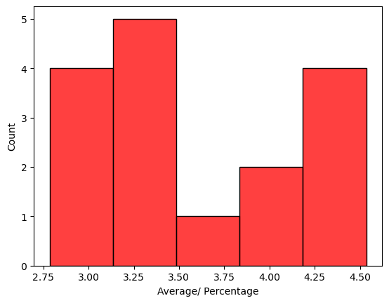

**Observation.**

**High Usage:**

**Lower Usage:**

**20. The overall quality of the teaching-learning process in your institute is very good.**

[output not shown]

[output not shown]

[figure not shown]

**Observation.**

**Recommendations:**

Investigate best practices: Explore how programs with high ratings (e.g., Bachelor of Arts, Bachelor of Commerce (Banking and Insurance)) effectively structure their teaching and learning. This could involve factors like curriculum design, classroom pedagogy, or student support services. Address areas for improvement: Identify areas needing improvement in programs with lower ratings (e.g., Bachelor of Commerce). Gather more specific feedback through surveys or focus groups to understand student concerns.